# Pregnancy Detection with Machine Learning

## Part Two: Recurrent Neural Networks

In this section I use one of the most important RNNs: Long Short Term Memory networks (LSTM). One application of LSTM is in language models and speech recognition problems, since their data is usually in sequential format. It can also be applied to the wrist pulse data because the raw data is also a sequence.

### 1) Data preparation

This dataset only contains unpregnant and late-pregnant patients.

```python
data2 = pd.read_csv('/Users/Chao/Desktop/Pulse/binary_data.csv')
```

```python
data2.shape
```

```
(343, 1085)
```

```python
data2.head(10)
```

|  | 0 | 1 | 2 | 3 | 4 | 5 | 6 | 7 | 8 | 9 | ... | 1075 | 1076 | 1077 | 1078 | 1079 | 1080 | 1081 | 1082 | 1083 | 1084 |
| --- | --- | --- | --- | --- | --- | --- | --- | --- | --- | --- | --- | --- | --- | --- | --- | --- | --- | --- | --- | --- | --- |
| 0 | 0 | 38.980392 | 36.058824 | 34.715686 | 30.941176 | 27.166667 | 18.754902 | 7.676471 | -3.166667 | -14.137255 | ... | -40.578431 | -36.676471 | -29.607843 | -19.254902 | -3.166667 | 17.666667 | 41.911765 | 67.372549 | 91.617647 | 114.156863 |
| 1 | 0 | -274.862745 | -272.058824 | -269.745098 | -265.843137 | -257.441176 | -245.500000 | -231.245098 | -215.529412 | -197.745098 | ... | -34.970588 | -34.235294 | -34.970588 | -35.941176 | -35.705882 | -35.705882 | -35.941176 | -37.647059 | -40.813725 | -43.617647 |
| 2 | 0 | 140.960784 | 132.549020 | 122.803922 | 113.176471 | 104.892157 | 97.460784 | 90.274510 | 84.911765 | 79.186275 | ... | -84.196078 | -81.754902 | -68.470588 | -40.696078 | -3.166667 | 38.127451 | 76.019608 | 107.333333 | 130.362745 | 144.009804 |
| 3 | 0 | -322.715686 | -322.715686 | -322.715686 | -322.715686 | -322.715686 | -322.715686 | -322.715686 | -322.715686 | -322.715686 | ... | -38.137255 | -38.382353 | -40.813725 | -41.911765 | -42.156863 | -40.941176 | -39.725490 | -37.774510 | -35.460784 | -29.852941 |
| 4 | 0 | 89.421569 | 85.647059 | 83.941176 | 82.480392 | 81.745098 | 81.745098 | 80.892157 | 78.578431 | 74.803922 | ... | -24.009804 | -26.686275 | -31.196078 | -34.480392 | -37.647059 | -39.725490 | -41.303922 | -42.284314 | -42.764706 | -43.009804 |
| 5 | 0 | 53.725490 | 48.117647 | 44.098039 | 40.931373 | 38.254902 | 34.715686 | 28.627451 | 22.656863 | 16.686275 | ... | 52.509804 | 47.637255 | 45.078431 | 43.245098 | 43.735294 | 44.705882 | 45.558824 | 45.686275 | 45.558824 | 46.294118 |
| 6 | 0 | 42.029412 | 38.127451 | 34.843137 | 32.647059 | 29.480392 | 27.656863 | 24.117647 | 20.833333 | 16.931373 | ... | 86.990196 | 81.019608 | 72.127451 | 64.205882 | 57.500000 | 50.921569 | 45.196078 | 42.029412 | 39.833333 | 39.715686 |
| 7 | 0 | -2.558824 | -4.147059 | -5.245098 | -6.343137 | -7.313725 | -8.774510 | -10.480392 | -11.333333 | -11.941176 | ... | 11.813725 | 11.078431 | 10.470588 | 11.078431 | 11.568627 | 12.176471 | 11.323529 | 10.843137 | 9.500000 | 7.303922 |
| 8 | 0 | 163.009804 | 158.137255 | 153.147059 | 149.490196 | 144.862745 | 138.156863 | 130.480392 | 118.421569 | 102.333333 | ... | 36.911765 | 55.921569 | 66.637255 | 70.294118 | 68.098039 | 61.764706 | 55.794118 | 52.509804 | 52.990196 | 56.647059 |
| 9 | 0 | -198.833333 | -201.764706 | -206.637255 | -210.901961 | -216.500000 | -225.637255 | -245.009804 | -266.088235 | -287.774510 | ... | -12.431373 | -13.774510 | -15.352941 | -16.205882 | -18.156863 | -20.352941 | -21.686275 | -24.009804 | -25.470588 | -26.078431 |

10 rows × 1085 columns

```python
# shift the data so that there will be no negative values and normalize
                    temp = data2
                    res = data2

                    for row in list(temp.index):
                    min_val = min(temp.iloc[row][1:])
                    max_val = max(temp.iloc[row][1:])
                    for col in list(temp.columns.values)[1:]:
                    res.set_value(row, col, ((temp.iloc[row][col] + abs(min_val))*100.0/(max_val + abs(min_val))))
```

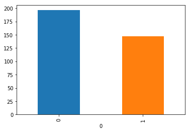

```python
res.groupby('0').size().plot(kind='bar')
```

```python
res.head(10)
```

|  | 0 | 1 | 2 | 3 | 4 | 5 | 6 | 7 | 8 | 9 | ... | 1075 | 1076 | 1077 | 1078 | 1079 | 1080 | 1081 | 1082 | 1083 | 1084 |
| --- | --- | --- | --- | --- | --- | --- | --- | --- | --- | --- | --- | --- | --- | --- | --- | --- | --- | --- | --- | --- | --- |
| 0 | 0 | 54.924255 | 53.918823 | 53.456594 | 52.157630 | 50.858666 | 47.963831 | 44.151287 | 40.419717 | 36.644286 | ... | 27.544789 | 28.887614 | 31.320220 | 34.883093 | 40.419717 | 47.589325 | 55.933061 | 64.695165 | 73.038901 | 80.795573 |
| 1 | 0 | 0.000000 | 0.481571 | 0.878951 | 1.549108 | 2.992137 | 5.043021 | 7.491286 | 10.190439 | 13.244877 | ... | 41.201233 | 41.327519 | 41.201233 | 41.034535 | 41.074947 | 41.074947 | 41.034535 | 40.741551 | 40.197680 | 39.716109 |
| 2 | 0 | 90.894109 | 87.885694 | 84.400421 | 80.957223 | 77.994390 | 75.336606 | 72.766480 | 70.848527 | 68.800842 | ... | 10.368163 | 11.241234 | 15.992286 | 25.925666 | 39.347826 | 54.116410 | 67.668303 | 78.867461 | 87.103787 | 91.984572 |
| 3 | 0 | 0.000000 | 0.000000 | 0.000000 | 0.000000 | 0.000000 | 0.000000 | 0.000000 | 0.000000 | 0.000000 | ... | 79.428102 | 79.359694 | 78.681078 | 78.374607 | 78.306198 | 78.645506 | 78.984813 | 79.529347 | 80.175127 | 81.740320 |
| 4 | 0 | 86.732412 | 84.775315 | 83.890809 | 83.133388 | 82.752135 | 82.752135 | 82.309882 | 81.110207 | 79.153111 | ... | 27.917853 | 26.530094 | 24.191745 | 22.488817 | 20.846889 | 19.769215 | 18.950793 | 18.442456 | 18.193371 | 18.066287 |
| 5 | 0 | 49.662799 | 47.266787 | 45.549365 | 44.196372 | 43.052821 | 41.540653 | 38.939388 | 36.388389 | 33.837390 | ... | 49.143384 | 47.061534 | 45.968249 | 45.184937 | 45.394379 | 45.809073 | 46.173501 | 46.227956 | 46.173501 | 46.487664 |
| 6 | 0 | 61.285560 | 59.326705 | 57.677921 | 56.575450 | 54.985727 | 54.070283 | 52.293533 | 50.644748 | 48.685894 | ... | 83.856679 | 80.859337 | 76.395314 | 72.418545 | 69.052072 | 65.749582 | 62.875283 | 61.285560 | 60.183089 | 60.124028 |
| 7 | 0 | 45.268211 | 44.033831 | 43.180433 | 42.327034 | 41.572691 | 40.437367 | 39.111551 | 38.448644 | 37.976227 | ... | 56.438586 | 55.867114 | 55.394697 | 55.867114 | 56.248095 | 56.720512 | 56.057604 | 55.684243 | 54.640354 | 52.933557 |
| 8 | 0 | 86.422806 | 85.072153 | 83.688888 | 82.675218 | 81.392505 | 79.533658 | 77.405767 | 74.063103 | 69.603500 | ... | 51.468870 | 56.738321 | 59.708672 | 60.722341 | 60.113596 | 58.358018 | 56.702992 | 55.792592 | 55.925755 | 56.939424 |
| 9 | 0 | 25.555668 | 24.950956 | 23.945798 | 23.066033 | 21.911214 | 20.026292 | 16.029932 | 11.681666 | 7.208009 | ... | 64.008494 | 63.731419 | 63.405804 | 63.229851 | 62.827384 | 62.374355 | 62.099302 | 61.619982 | 61.318637 | 61.193245 |

10 rows × 1085 columns

```python
X = res.iloc[:, 1:]
                    y = res[['0']]
```

```python
from sklearn.cross_validation import train_test_split
                    X_train, X_test, y_train, y_test = train_test_split(X, y, test_size=0.10)
```

### 2) Build LSTM

```python
import tensorflow as tf
```

```python
# define two variables which will hold the input data and the target data.
                    data = tf.placeholder(tf.float32, [None, 1084,1])
                    target = tf.placeholder(tf.float32, [None, 1])
```

```python
# define cell parameters and build computation graph
                    num_hidden = 10
                    cell = tf.nn.rnn_cell.LSTMCell(num_hidden,state_is_tuple=True)

                    val, state = tf.nn.dynamic_rnn(cell, data, dtype=tf.float32)

                    val = tf.transpose(val, [1, 0, 2])
                    last = tf.gather(val, int(val.get_shape()[0]) - 1)

                    weight = tf.Variable(tf.truncated_normal([num_hidden, int(target.get_shape()[1])]))
                    bias = tf.Variable(tf.constant(0.1, shape=[target.get_shape()[1]]))
```

```python
# define weights and biases, and multiply the output with the weights and add the bias values to it
                    prediction = tf.nn.softmax(tf.matmul(last, weight) + bias)
```

```python
# calculate the cross entropy loss to use as the cost function.
                    cross_entropy = -tf.reduce_sum(target * tf.log(tf.clip_by_value(prediction,1e-10,1.0)))
```

```python
# AdamOptimizer
                    optimizer = tf.train.AdamOptimizer()
                    minimize = optimizer.minimize(cross_entropy)
```

```python
# this error gives a rough idea of the correctness of the model on the test dataset.
                    mistakes = tf.not_equal(tf.argmax(target, 1), tf.argmax(prediction, 1))
                    error = tf.reduce_mean(tf.cast(mistakes, tf.float32))
```

### 3) Execute the tensorflow graph

```python
# begin session and initialize training variables
                    init_op = tf.global_variables_initializer()
                    sess = tf.Session()
                    sess.run(init_op)
```

```python
# stochastic optimization
                    batch_size = 50
                    no_of_batches = int(len(X_train)/batch_size)
                    epoch = 100
                    for i in range(epoch):
                    ptr = 0
                    for j in range(no_of_batches):
                    inp, out = X_train[ptr:ptr+batch_size], y_train[ptr:ptr+batch_size]
                    ptr+=batch_size
                    sess.run(minimize,{data: inp, target: out})
                    print("Epoch - "+str(i))
                    incorrect = sess.run(error,{data: X_test, target: y_test})
                    print('Epoch {:2d} error {:3.1f}%'.format(i + 1, 100 * incorrect))
                    sess.close()
```

[output not shown]